# Final_Project

Sunday Okechukwu & Dhanush Kikkisetti

2023-04-10

1. Offer a preliminary description of the data set. For example, indicate the size of the data source, describe the variables, and include any other data profile information that would be of interest.

## Data Source

[click here view the data source on github](https://github.com/dcgerard/stat_415_615/blob/main/lectures/data/estate.csv)

## Brief Description of the dataset:

This dataset is about 522 home sales in a Midwestern city during the year 2002. The goal here is to predict residential home sales prices from the other variables.

> The 13 variables are described below:
- price: Sales price of residence (in dollars)
- area: Finished area of residence (in square feet)
- bed: Total number of bedrooms in residence
- bath: Total number of bathrooms in residence
- ac: “yes” = presence of air conditioning, “no” = absence of air conditioning
- garage: Number of cars that a garage will hold
- pool: “yes” = presence of a pool, “no” = absence of a pool
- year: Year property was originally constructed
- quality: Index for quality of construction. high, medium, or low.
- style: Categorical variable indicating architectural style
- lot: Lot size (in square feet)
- highway: “yes” = highway adjacent, “no” = highway not adjacent.

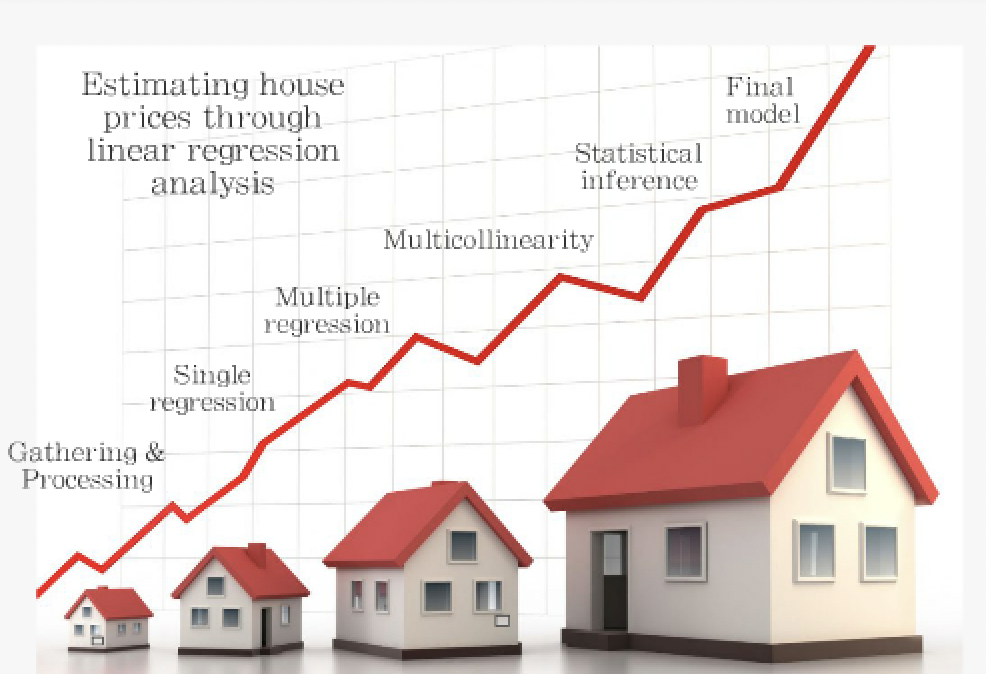

# Data Downloading

```r
# Set the URL of the CSV file to download
url <- "https://dcgerard.github.io/stat_415_615/data/estate.csv"

# Check if a folder named "data" exists in the current working directory
if (!file.exists("data")) {
  # If it doesn't exist, create it
  dir.create("data")
}

# Set the file path for the downloaded CSV file
file_path <- file.path("data", "estate.csv")

# Download the CSV file from the specified URL and save it to the file path
download.file(url, file_path, method = "auto")
```

```r
# Read the CSV file into R
estate <- read.csv(file_path)

# View the first few rows of the data to confirm that it was loaded correctly
head(estate)
```

```
##   id  price area bed bath  ac garage pool year quality style   lot highway
## 1  1 360000 3032   4    4 yes      2   no 1972  medium     1 22221      no
## 2  2 340000 2058   4    2 yes      2   no 1976  medium     1 22912      no
## 3  3 250000 1780   4    3 yes      2   no 1980  medium     1 21345      no
## 4  4 205500 1638   4    2 yes      2   no 1963  medium     1 17342      no
## 5  5 275500 2196   4    3 yes      2   no 1968  medium     7 21786      no
## 6  6 248000 1966   4    3 yes      5  yes 1972  medium     1 18902      no
```

```r
#Let's drop the id column columns
estate %>%
  select(-id) -> estate
```

```r
# check for null values
# count the number of null values
sum(is.na(estate))
```

```
## [1] 0
```

2. Generate relevant data visual plots that explore multicollinearity for the quantitative variables and normality for the quantitative variables as well. Also, use R code to confirm the levels of the categorical variables.

```r
## Exploring the quantitative variables
quant_variables <- estate %>%
  select(price, area, bed, bath, garage,
        year,style, lot)
head(quant_variables)
```

```
##    price area bed bath garage year style   lot
## 1 360000 3032   4    4      2 1972     1 22221
## 2 340000 2058   4    2      2 1976     1 22912
## 3 250000 1780   4    3      2 1980     1 21345
## 4 205500 1638   4    2      2 1963     1 17342
## 5 275500 2196   4    3      2 1968     7 21786
## 6 248000 1966   4    3      5 1972     1 18902
```

# Lets visualize the correlation

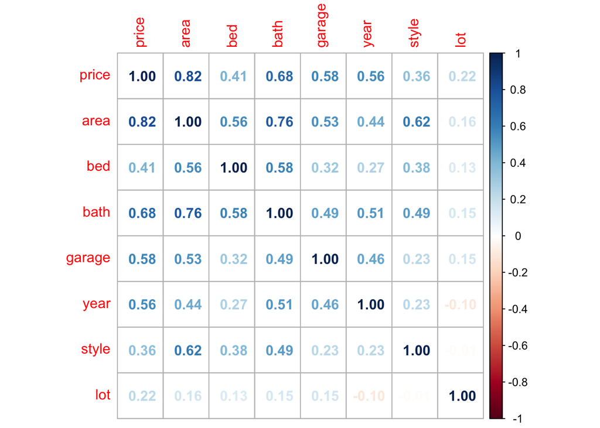

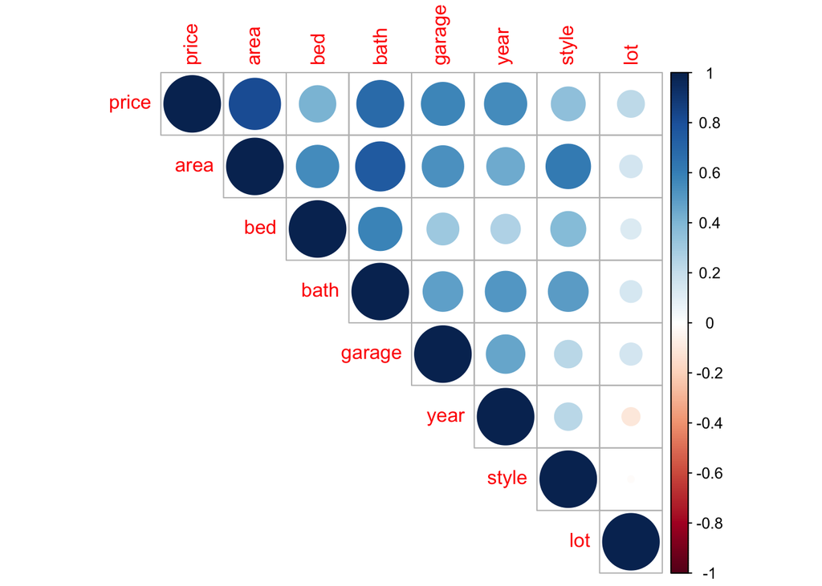

#### Observation

`It appears there's multicollinearity between some explanatory variables. For example, bath is highly correlated with area with correlation coefficient of 0.76, area and style are also moderately correlated`

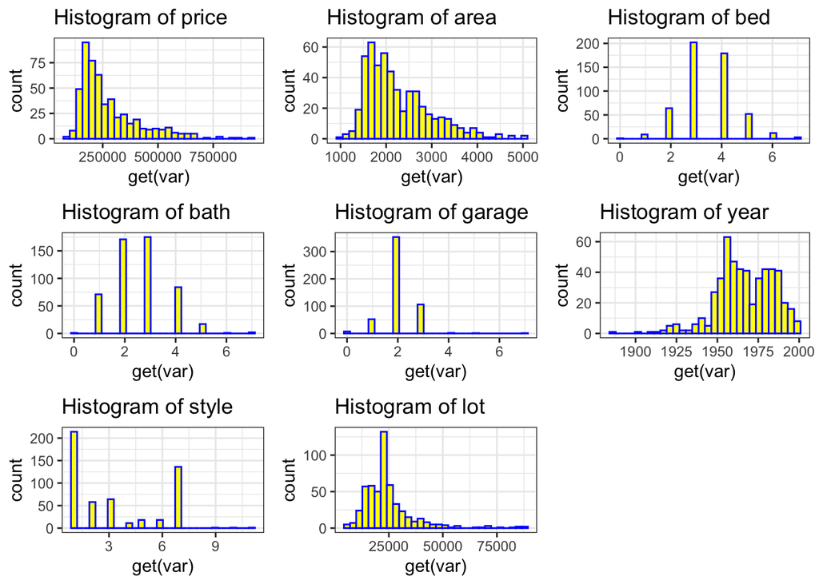

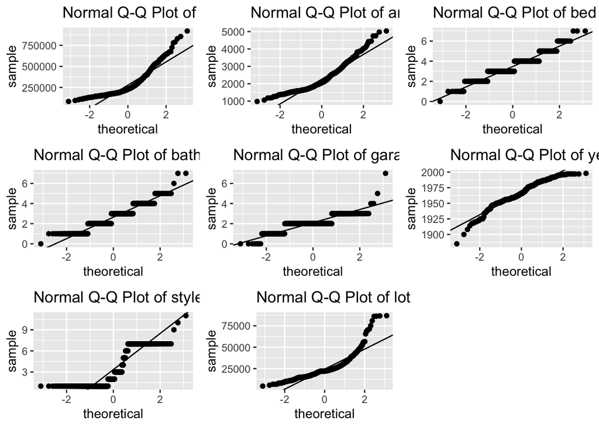

## Checking the data type of the data frame

```r
str(estate)
```

```
## 'data.frame':    522 obs. of  12 variables:
##  $ price  : int  360000 340000 250000 205500 275500 248000 229900 150000 195000 160000 ...
##  $ area   : int  3032 2058 1780 1638 2196 1966 2216 1597 1622 1976 ...
##  $ bed    : int  4 4 4 4 4 4 3 2 3 3 ...
##  $ bath   : int  4 2 3 2 3 3 2 1 2 3 ...
##  $ ac     : Factor w/ 2 levels "no","yes": 2 2 2 2 2 2 2 2 2 1 ...
##  $ garage : int  2 2 2 2 2 5 2 1 2 1 ...
##  $ pool   : Factor w/ 2 levels "no","yes": 1 1 1 1 1 2 1 1 1 1 ...
##  $ year   : int  1972 1976 1980 1963 1968 1972 1972 1955 1975 1918 ...
##  $ quality: Factor w/ 3 levels "high","low","medium": 3 3 3 3 3 3 3 3 2 2 ...
##  $ style  : int  1 1 1 1 7 1 7 1 1 1 ...
##  $ lot    : int  22221 22912 21345 17342 21786 18902 18639 22112 14321 32358 ...
##  $ highway: Factor w/ 2 levels "no","yes": 1 1 1 1 1 1 1 1 1 1 ...
```

## Checking for the factor levels

```
## ac :
## [1] "no"  "yes"
## pool :
## [1] "no"  "yes"
## quality :
## [1] "high"   "low"    "medium"
## highway :
## [1] "no"  "yes"
```

3. Using R code, produce a full Regression Model that consists of quantitative and categorical variables. Make use of the R generated dummy variable matrices

```r
# produce a full Regression Model that consists of quantitative and categorical variables
model <- lm(price ~ ., estate)
model
```

```
##
## Call:
## lm(formula = price ~ ., data = estate)
##
## Coefficients:
##   (Intercept)           area            bed           bath          acyes
##    -2.365e+06      1.042e+02     -5.053e+03      9.605e+03      2.467e+03
##        garage        poolyes           year     qualitylow  qualitymedium
##     9.207e+03      8.180e+03      1.262e+03     -1.371e+05     -1.312e+05
##         style            lot     highwayyes
##    -6.324e+03      1.389e+00     -3.481e+04
```

```r
options(scipen = 3)
summary(model)
```

```
##
## Call:
## lm(formula = price ~ ., data = estate)
##
## Residuals:
##     Min      1Q  Median      3Q     Max
## -214251  -27600   -3322   22639  266535
##
## Coefficients:
##                    Estimate    Std. Error t value Pr(>|t|)
## (Intercept)   -2364826.9266   390894.4235  -6.050 2.81e-09 ***
## area               104.1569        7.3795  14.114  < 2e-16 ***
## bed              -5052.7062     3207.9523  -1.575   0.1159
## bath              9604.6441     4211.8982   2.280   0.0230 *
## acyes             2467.2373     7935.9029   0.311   0.7560
## garage            9207.0433     4969.0235   1.853   0.0645 .
## poolyes           8179.7187    10198.9116   0.802   0.4229
## year              1261.6070      198.2488   6.364 4.40e-10 ***
## qualitylow     -137123.5828    13959.5326  -9.823  < 2e-16 ***
## qualitymedium  -131154.4179    10304.7324 -12.728  < 2e-16 ***
## style            -6324.3883     1331.5423  -4.750 2.65e-06 ***
## lot                  1.3891        0.2341   5.933 5.51e-09 ***
## highwayyes      -34806.9564    17797.8467  -1.956   0.0510 .
## ---
## Signif. codes:  0 '***' 0.001 '**' 0.01 '*' 0.05 '.' 0.1 ' ' 1
##
## Residual standard error: 57560 on 509 degrees of freedom
## Multiple R-squared:  0.8298, Adjusted R-squared:  0.8258
## F-statistic: 206.8 on 12 and 509 DF,  p-value: < 2.2e-16
```

### Observations

4. Using only the quantitative variables as predictors, produce a model using matrix methods. Also use matrix methods to find the fitted values and the residuals .

```r
# Create a matrix of the predictor variables
X <- as.matrix(quant_variables[, -1])
X <- cbind(1, X)

# Create a vector of the response variable
y <- as.matrix(quant_variables[, 1])

# Calculate the beta coefficients using matrix methods
beta <- solve(t(X) %*% X) %*% t(X) %*% y
beta
```

```
##                  [,1]
##        -3385616.21927
## area        148.92043
## bed      -12005.85204
## bath      10634.88740
## garage    17934.39512
## year       1680.86891
## style    -10323.23037
## lot           1.28042
```

```r
# Confirm the above values
fit <- lm(price ~ . , quant_variables)
fit
```

```
##
## Call:
## lm(formula = price ~ ., data = quant_variables)
##
## Coefficients:
## (Intercept)         area          bed         bath       garage         year
## -3385616.22       148.92    -12005.85     10634.89     17934.40      1680.87
##       style          lot
##   -10323.23         1.28
```

```r
# Calculate the fitted values and residuals
yhat <- X %*% beta
residuals <- y - yhat

as.tibble(data.frame(fitted_values = yhat, residuals = residuals))
```

```
## # A tibble: 522 × 2
##    fitted_values residuals
##            <dbl>     <dbl>
##  1       429098.   -69098.
##  2       270388.    69612.
##  3       244340.     5660.
##  4       178858.    26642.
##  5       224746.    50754.
##  6       309267.   -61267.
##  7       231789.    -1889.
##  8       160855.   -10855.
##  9       204783.    -9783.
## 10       177487.   -17487.
## # … with 512 more rows
```

5. Produce an output summary table to be used to analyze and evaluate the full model (Adjusted R squared, Standard Error, Significance of Variables, etc…)

```r
summary(model)
```

```
##
## Call:
## lm(formula = price ~ ., data = estate)
##
## Residuals:
##     Min      1Q  Median      3Q     Max
## -214251  -27600   -3322   22639  266535
##
## Coefficients:
##                    Estimate    Std. Error t value Pr(>|t|)
## (Intercept)   -2364826.9266   390894.4235  -6.050 2.81e-09 ***
## area               104.1569        7.3795  14.114  < 2e-16 ***
## bed              -5052.7062     3207.9523  -1.575   0.1159
## bath              9604.6441     4211.8982   2.280   0.0230 *
## acyes             2467.2373     7935.9029   0.311   0.7560
## garage            9207.0433     4969.0235   1.853   0.0645 .
## poolyes           8179.7187    10198.9116   0.802   0.4229
## year              1261.6070      198.2488   6.364 4.40e-10 ***
## qualitylow     -137123.5828    13959.5326  -9.823  < 2e-16 ***
## qualitymedium  -131154.4179    10304.7324 -12.728  < 2e-16 ***
## style            -6324.3883     1331.5423  -4.750 2.65e-06 ***
## lot                  1.3891        0.2341   5.933 5.51e-09 ***
## highwayyes      -34806.9564    17797.8467  -1.956   0.0510 .
## ---
## Signif. codes:  0 '***' 0.001 '**' 0.01 '*' 0.05 '.' 0.1 ' ' 1
##
## Residual standard error: 57560 on 509 degrees of freedom
## Multiple R-squared:  0.8298, Adjusted R-squared:  0.8258
## F-statistic: 206.8 on 12 and 509 DF,  p-value: < 2.2e-16
```

6. Use procedures and techniques explored in class to produce confidence intervals for the independent quantitative variables of your model. Choose at least two of the quantitative variables to find confidence intervals for.

```r
# Find confidence intervals for two quantitative variables
confint(model, level = 0.95, "area")
```

```
##         2.5 %   97.5 %
## area 89.65882 118.6549
```

```r
confint(model, level = 0.95, "bed")
```

```
##         2.5 %   97.5 %
## bed -11355.16 1249.751
```

This means that we are 95% confident that the true population coefficient for the `bed` variable (i.e., the effect of the number of bedrooms on the price in the population) lies within this range. In other words, if we were to repeat our data collection and analysis many times, we would expect the coefficient for the `bed` variable to fall within this range in 95% of cases.

7. Now produce a reduced model (removing variables of your choice with justification). Use R summary coding for both models and offer justification for choosing one model over the other.

### Justications

Here variables that are not statistically significant are removed

```r
model <- lm(price ~ area + bath + year + quality + style + lot, data = estate)
summary(model)
```

```
##
## Call:
## lm(formula = price ~ area + bath + year + quality + style + lot,
##     data = estate)
##
## Residuals:
##     Min      1Q  Median      3Q     Max
## -214817  -27771   -4192   22707  267791
##
## Coefficients:
##                    Estimate    Std. Error t value Pr(>|t|)
## (Intercept)   -2452207.0163   379854.2755  -6.456 2.50e-10 ***
## area               104.1812        7.0854  14.704  < 2e-16 ***
## bath              8690.0665     4033.9315   2.154   0.0317 *
## year              1312.4131      191.2412   6.863 1.95e-11 ***
## qualitylow     -145083.3068    13638.7145 -10.638  < 2e-16 ***
## qualitymedium  -136843.2178    10102.3532 -13.546  < 2e-16 ***
## style            -6373.1788     1325.8285  -4.807 2.02e-06 ***
## lot                  1.3608        0.2293   5.934 5.45e-09 ***
## ---
## Signif. codes:  0 '***' 0.001 '**' 0.01 '*' 0.05 '.' 0.1 ' ' 1
##
## Residual standard error: 57880 on 514 degrees of freedom
## Multiple R-squared:  0.8262, Adjusted R-squared:  0.8239
## F-statistic: 349.1 on 7 and 514 DF,  p-value: < 2.2e-16
```

### All the predictor variable are statistically signicant indicating that we can reject the null hypothesis that the predictor variables has no effect on dependent variable that their estimate coefficients are zero.

8. Research and apply a model analysis technique not discussed in class to your full model or reduced model. Fully explain the technique or procedure and how it is being applied to your specific model.

`I suggest the following`

- Leverage
- Cook’s distance
- studentized
- Stepwise regression

Stepwise regression is a method of fitting a multiple regression model to a dataset in which the variables are selected in a step-by-step manner based on their statistical significance. The goal of stepwise regression is to identify a subset of the most important predictor variables that have the greatest impact on the outcome variable while minimizing overfitting.

There are two main approaches to stepwise regression: forward selection and backward elimination. Both approaches are iterative, meaning that they involve running a sequence of regression models with different subsets of predictor variables.

In forward selection, the algorithm starts with a model that includes only the intercept and then adds the predictor variable that has the highest correlation with the outcome variable. It continues to add predictor variables one at a time, stopping when all remaining predictor variables have a p-value above a certain threshold or when adding more variables no longer improves the model’s overall fit.

In backward elimination, the algorithm starts with a model that includes all predictor variables and then removes the variable with the highest p-value (i.e., the least statistically significant variable). It continues to remove predictor variables one at a time, stopping when all remaining predictor variables have a p-value below a certain threshold or when removing more variables no longer improves the model’s overall fit.

Both forward selection and backward elimination can result in different final models, depending on the data and the criteria used to determine statistical significance. Therefore, it is important to evaluate the model’s performance on an independent dataset to avoid over fitting and to assess the model’s predictive accuracy.

```r
#define model with all predictors
all <- lm(price ~ ., data=estate)
all
```

```
##
## Call:
## lm(formula = price ~ ., data = estate)
##
## Coefficients:
##   (Intercept)           area            bed           bath          acyes
##  -2364826.927        104.157      -5052.706       9604.644       2467.237
##        garage        poolyes           year     qualitylow  qualitymedium
##      9207.043       8179.719       1261.607    -137123.583    -131154.418
##         style            lot     highwayyes
##     -6324.388          1.389     -34806.956
```

```r
#perform forward stepwise regression
forward <- step(all, direction='forward', scope=formula(all), trace=0)
forward
```

```
##
## Call:
## lm(formula = price ~ area + bed + bath + ac + garage + pool +
##     year + quality + style + lot + highway, data = estate)
##
## Coefficients:
##   (Intercept)           area            bed           bath          acyes
##  -2364826.927        104.157      -5052.706       9604.644       2467.237
##        garage        poolyes           year     qualitylow  qualitymedium
##      9207.043       8179.719       1261.607    -137123.583    -131154.418
##         style            lot     highwayyes
##     -6324.388          1.389     -34806.956
```

9. Offer final summary perspectives about the data and the models that you produce, suggesting how your models or model analysis enhanced your understanding of the data. (4 or 5 sentences)